# Median_MAD_Spearma_Correlation

Vamos explorar as propriedades das estatísticas robustas. Usaremos um dos conjuntos de dados incluídos em R, que contém o peso dos pintinhos em gramas à medida que crescem do dia 0 ao dia 21. Esse conjunto de dados também divide os pintinhos por diferentes dietas protéicas, que são codificadas de 1 a 4. Usamos este conjunto de dados também mostra uma operação importante em R (não relacionada a resumos robustos): remodelar.

Este conjunto de dados está integrado em R e pode ser carregado com:

```r
data(ChickWeight)
head(ChickWeight)
```

|  | weight | Time | Chick | Diet |
| --- | --- | --- | --- | --- |
| 1 | 42 | 0 | 1 | 1 |
| 2 | 51 | 2 | 1 | 1 |
| 3 | 59 | 4 | 1 | 1 |
| 4 | 64 | 6 | 1 | 1 |
| 5 | 76 | 8 | 1 | 1 |
| 6 | 93 | 10 | 1 | 1 |

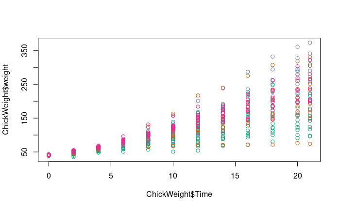

```r
plot( ChickWeight$Time, ChickWeight$weight, col=ChickWeight$Diet)
```

Primeiro, observe que as linhas aqui representam pontos no tempo e não indivíduos. Para facilitar a comparação de pesos em diferentes momentos e entre os diferentes pintinhos, remodelaremos os dados para que cada linha seja um pintinho. Em R podemos fazer isso com a função remodelar:

```r
chick = reshape(ChickWeight, idvar=c("Chick","Diet"), timevar="Time", direction="wide")
```

O significado desta linha é: remodelar os dados de longo para largo , onde as colunas Chick e Diet são os ID’s e a coluna Time indica observações diferentes para cada ID. Agora examine o cabeçalho deste conjunto de dados:

```r
head(chick)
```

|  | Chick | Diet | weight.0 | weight.2 | weight.4 | weight.6 | weight.8 | weight.10 | weight.12 | weight.14 | weight.16 | weight.18 | weight.20 | weight.21 |
| --- | --- | --- | --- | --- | --- | --- | --- | --- | --- | --- | --- | --- | --- | --- |
| 1 | 1 | 1 | 42 | 51 | 59 | 64 | 76 | 93 | 106 | 125 | 149 | 171 | 199 | 205 |
| 13 | 2 | 1 | 40 | 49 | 58 | 72 | 84 | 103 | 122 | 138 | 162 | 187 | 209 | 215 |
| 25 | 3 | 1 | 43 | 39 | 55 | 67 | 84 | 99 | 115 | 138 | 163 | 187 | 198 | 202 |
| 37 | 4 | 1 | 42 | 49 | 56 | 67 | 74 | 87 | 102 | 108 | 136 | 154 | 160 | 157 |
| 49 | 5 | 1 | 41 | 42 | 48 | 60 | 79 | 106 | 141 | 164 | 197 | 199 | 220 | 223 |
| 61 | 6 | 1 | 41 | 49 | 59 | 74 | 97 | 124 | 141 | 148 | 155 | 160 | 160 | 157 |

Também queremos remover quaisquer pintinhos que tenham observações perdidas em qualquer momento (NA para “não disponível”). A linha de código a seguir identifica essas linhas e as remove:

```r
chick = na.omit(chick)
```

Exercícios de correlação de mediana, MAD e Spearman nº 1

Concentre-se nos pesos dos pintinhos no dia 4 (verifique os nomes das colunas de ‘pintinho’ e anote os números). Quanto aumenta a média do peso dos pintinhos no dia 4 se adicionarmos uma medida atípica de 3.000 gramas? Especificamente, qual é o peso médio dos pintinhos do dia 4, incluindo o pintinho discrepante, dividido pela média do peso dos pintinhos do dia 4 sem o pintinho discrepante. Dica: use c para adicionar um número a um vetor.

```r
chickout<-c(chick$weight.4,3000) # adicionando o outlier de valor 3000
mean(chickout)/mean(chick$weight.4)
```

```
[1] 2.062407
```

Exercícios de mediana, MAD e correlação de Spearman nº 2

No exercício 1, vimos quão sensível a média é a valores discrepantes. Agora vamos ver o que acontece quando usamos a mediana em vez da média. Calcule a mesma proporção, mas agora usando a mediana em vez da média. Especificamente, qual é o peso médio dos pintinhos do dia 4, incluindo o pintinho discrepante, dividido pela mediana do peso dos pintinhos do dia 4 sem o pintinho discrepante.

```r
median(c(chick$weight.4, 3000))/median(chick$weight.4)
```

```
[1] 1
```

Exercícios de mediana, MAD e correlação de Spearman nº 3

Agora tente a mesma coisa com o desvio padrão da amostra (a função sd em R). Adicione um pintinho com peso de 3.000 gramas aos pesos dos pintinhos a partir do dia 4. Quanto muda o desvio padrão? Qual é o desvio padrão com o pintinho discrepante dividido pelo desvio padrão sem o pintinho discrepante?

```r
sd(c(chick$weight.4, 3000))/sd(chick$weight.4)
```

```
[1] 101.2859
```

Exercícios de correlação de mediana, MAD e Spearman nº 4

Compare o resultado acima com o desvio absoluto mediano em R, que é calculado com a função mad. Observe que o louco não é afetado pela adição de um único valor discrepante. A função mad em R inclui o fator de escala 1,4826, de modo que mad e sd são muito semelhantes para uma amostra de uma distribuição normal. Qual é o MAD com o pintinho discrepante dividido pelo MAD sem o pintinho discrepante?

```r
mad(c(chick$weight.4, 3000))/mad(chick$weight.4)
```

```
[1] 1
```

Exercícios de mediana, MAD e correlação de Spearman nº 5

Nossa última pergunta diz respeito a como a correlação de Pearson é afetada por um valor discrepante em comparação com a correlação de Spearman. A correlação de Pearson entre x e y é dada em R por cor(x,y). A correlação de Spearman é dada por cor(x,y,method=“spearman”).

Faça um gráfico dos pesos dos pintinhos do dia 4 e do dia 21. Podemos ver que há alguma tendência geral, com os pintinhos de peso mais baixo no dia 4 tendo peso baixo novamente no dia 21, e da mesma forma para os pintinhos de peso alto.

Calcule a correlação de Pearson dos pesos dos pintinhos do dia 4 e do dia 21. Agora calcule quanto a correlação de Pearson muda se adicionarmos um pintinho que pesa 3.000 no dia 4 e 3.000 no dia 21. Novamente, divida a correlação de Pearson com o pintinho discrepante sobre a correlação de Pearson calculada sem os outliers.

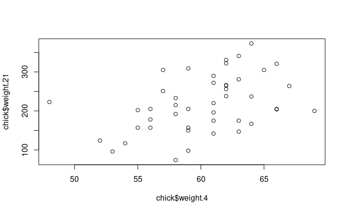

```r
plot(chick$weight.4,chick$weight.21)
```

```r
cor(chick$weight.4,chick$weight.21)
```

```
[1] 0.4159499
```

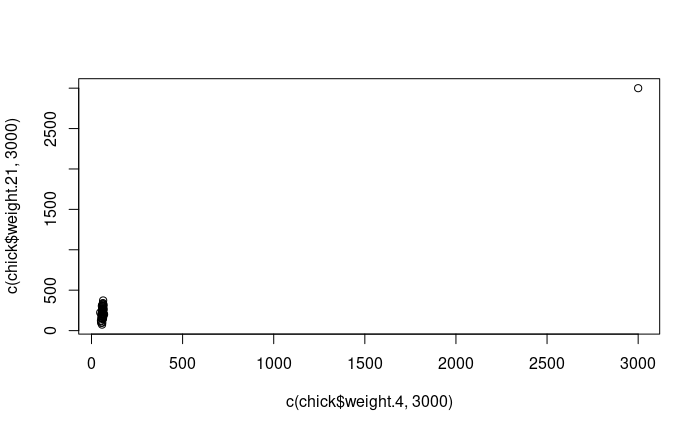

```r
plot(c(chick$weight.4,3000),c(chick$weight.21,3000))
```

```r
cor(c(chick$weight.4,3000),c(chick$weight.21,3000))
```

```
[1] 0.9861002
```

```r
cor(c(chick$weight.4,3000),c(chick$weight.21,3000))/cor(chick$weight.4,chick$weight.21)
```

```
[1] 2.370719
```